# 5. regresion_polinomial

## Universidad Politecnica Salesiana

#### Nombre: Erika Morocho

#### Asignatura: Simulación

### Covid-19 infección en Ecuador. Modelos matemáticos y predicciones

Una comparación de modelos, lineal, polilnomico,logísticos y exponenciales aplicados a la infección por el virus Covid-19

Se crea modelos de series temporales del número total de personas infectadas hasta la fecha (es decir, las personas realmente infectadas más las personas que han sido infectadas). Estos modelos tienen parámetros , que se estimarán por ajuste de curva.

```python
# Importar las librerias para el analasis
import pandas as pd
import numpy as np
from datetime import datetime,timedelta
from sklearn.metrics import mean_squared_error
from scipy.optimize import curve_fit
from scipy.optimize import fsolve
from sklearn import linear_model
import matplotlib.pyplot as plt
%matplotlib inline
```

```python
# Actualizar los datos (URL)
#https://github.com/owid/covid-19-data/tree/master/public/data
url = 'owid-covid-data.csv'
df = pd.read_csv(url)
df= df.fillna(0)
df.head()
```

|  | iso_code | continent | location | date | total_cases | new_cases | new_cases_smoothed | total_deaths | new_deaths | new_deaths_smoothed | ... | gdp_per_capita | extreme_poverty | cardiovasc_death_rate | diabetes_prevalence | female_smokers | male_smokers | handwashing_facilities | hospital_beds_per_thousand | life_expectancy | human_development_index |
| --- | --- | --- | --- | --- | --- | --- | --- | --- | --- | --- | --- | --- | --- | --- | --- | --- | --- | --- | --- | --- | --- |
| 0 | ABW | North America | Aruba | 2020-03-13 | 2.0 | 2.0 | 0.000 | 0.0 | 0.0 | 0.0 | ... | 35973.781 | 0.0 | 0.0 | 11.62 | 0.0 | 0.0 | 0.0 | 0.0 | 76.29 | 0.0 |
| 1 | ABW | North America | Aruba | 2020-03-19 | 0.0 | 0.0 | 0.286 | 0.0 | 0.0 | 0.0 | ... | 35973.781 | 0.0 | 0.0 | 11.62 | 0.0 | 0.0 | 0.0 | 0.0 | 76.29 | 0.0 |
| 2 | ABW | North America | Aruba | 2020-03-20 | 4.0 | 2.0 | 0.286 | 0.0 | 0.0 | 0.0 | ... | 35973.781 | 0.0 | 0.0 | 11.62 | 0.0 | 0.0 | 0.0 | 0.0 | 76.29 | 0.0 |
| 3 | ABW | North America | Aruba | 2020-03-21 | 0.0 | 0.0 | 0.286 | 0.0 | 0.0 | 0.0 | ... | 35973.781 | 0.0 | 0.0 | 11.62 | 0.0 | 0.0 | 0.0 | 0.0 | 76.29 | 0.0 |
| 4 | ABW | North America | Aruba | 2020-03-22 | 0.0 | 0.0 | 0.286 | 0.0 | 0.0 | 0.0 | ... | 35973.781 | 0.0 | 0.0 | 11.62 | 0.0 | 0.0 | 0.0 | 0.0 | 76.29 | 0.0 |

5 rows × 50 columns

Imprimos los resultados y agregamos el numero del dia

```python
df = df[df['location'].isin(['Ecuador'])] #Filtro la Informacion solo para Ecuador
df = df.loc[:,['date','total_cases', 'new_cases']] #Selecciono las columnas de analasis
# Expresar las fechas en numero de dias desde el 01 Enero
FMT = '%Y-%m-%d'
date = df['date']
df['date'] = date.map(lambda x : (datetime.strptime(x, FMT) - datetime.strptime("2020-01-01", FMT)).days)

df.head()
```

|  | date | total_cases | new_cases |
| --- | --- | --- | --- |
| 16001 | 22 | 0.0 | 0.0 |
| 16002 | 23 | 0.0 | 0.0 |
| 16003 | 24 | 0.0 | 0.0 |
| 16004 | 25 | 0.0 | 0.0 |
| 16005 | 26 | 0.0 | 0.0 |

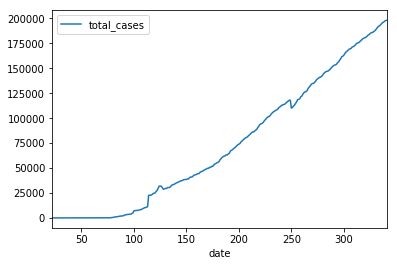

```python
df.plot(x ='date', y='total_cases')
```

### EL modelo lineal

La regresión lineal es un algoritmo de aprendizaje supervisado que se utiliza en Machine Learning y en estadística. En su versión más sencilla, lo que haremos es «dibujar una recta» que nos indicará la tendencia de un conjunto de datos continuos.

Recordemos rápidamente la fórmula de la recta:

**Y = mX + b**

Donde Y es el resultado, X es la variable, m la pendiente (o coeficiente) de la recta y b la constante o también conocida como el «punto de corte con el eje Y» en la gráfica (cuando X=0) Ejemplo

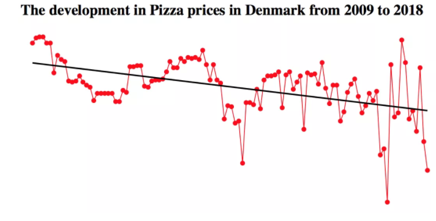

Recordemos que los algoritmos de Machine Learning Supervisados, aprenden por sí mismos y -en este caso- a obtener automáticamente esa «recta» que buscamos con la tendencia de predicción. Para hacerlo se mide el error con respecto a los puntos de entrada y el valor «Y» de salida real.

```python
x = list(df.iloc [:, 0]) # Fecha
y = list(df.iloc [:, 1]) # Numero de casos
# Creamos el objeto de Regresión Lineal
regr = linear_model.LinearRegression()

# Entrenamos nuestro modelo
regr.fit(np.array(x).reshape(-1, 1) ,y)

# Veamos los coeficienetes obtenidos, En nuestro caso, serán la Tangente
print('Coefficients: \n', regr.coef_)
# Este es el valor donde corta el eje Y (en X=0)
print('Independent term: \n', regr.intercept_)
```

```
Coefficients:
 [678.23434836]
Independent term:
 -50243.115476957784
```

De la ecuación de la recta y = mX + b nuestra pendiente «m» es el coeficiente y el término independiente «b»

```python
#Vamos a comprobar:
# Quiero predecir cuántos "Casos" voy a obtener por en el dia 100,
# según nuestro modelo, hacemos:
y_prediccion = regr.predict([[100]])
print('Para el dia 100 el numero de casos son:',int(y_prediccion))
```

```
Para el dia 100 el numero de casos son: 17580
```

```
[50 51 52 53 54 55 56 57 58 59 60 61 62 63 64 65 66 67 68 69 70 71 72 73
 74 75 76 77 78 79 80 81 82 83 84 85 86 87 88 89 90 91 92 93 94 95 96 97
 98 99]
```

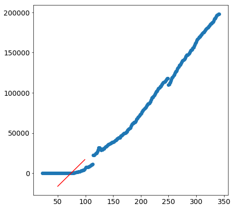

```python
#Graficar
plt.scatter(x, y)
x_real = np.array(range(50, 100))
print(x_real)
plt.plot(x_real, regr.predict(x_real.reshape(-1, 1)), color='red')
plt.show()
```

### El modelo logistico

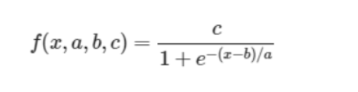

En esta fórmula, tenemos la variable x que es el tiempo y tres parámetros: a, b, c .

- a se refiere a la velocidad de infección
- b es el día en que ocurrieron las infecciones máximas
- c es el número total de personas infectadas registradas al final de la infección

A continuacion se puede apreciar un ejemplo de regresion logistica

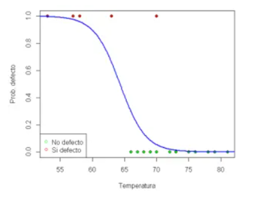

```python
def modelo_logistico(x,a,b):
    return a+b*np.log(x)

exp_fit = curve_fit(modelo_logistico,x,y) #Extraemos los valores de los paramatros
print(exp_fit)
```

```
(array([-343832.62635712,   83019.89950144]), array([[ 1.73473472e+08, -3.39535647e+07],
       [-3.39535647e+07,  6.76480830e+06]]))
```

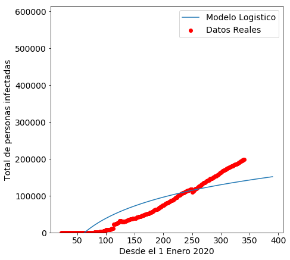

```python
# Graficas
pred_x = list(range(min(x),max(x)+50)) # Predecir 50 dias mas
plt.rcParams['figure.figsize'] = [7, 7]
plt.rc('font', size=14)
# Real data
plt.scatter(x,y,label="Datos Reales",color="red")
# Predicted exponential curve
plt.plot(pred_x, [modelo_logistico(i,exp_fit[0][0],exp_fit[0][1]) for i in pred_x], label="Modelo Logistico" )
plt.legend()
plt.xlabel("Desde el 1 Enero 2020")
plt.ylabel("Total de personas infectadas")
plt.ylim((min(y)*0.9,max(y)*3.1)) # Definir los limites de Y
plt.show()
```

### Modelo exponencial

Un modelo, de fácil interpretación geométrica, que puede ser utilizado para la representación de los casos por cada día, es el modelo exponencial debido a que describe un crecimiento de infección que se detendrá en el futuro, el modelo exponencial describe un crecimiento de infección imparable . Por ejemplo, si un paciente infecta a 2 pacientes por día, después de 1 día tendremos 2 infecciones, 4 después de 2 días, 8 después de 3 y así sucesivamente.

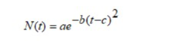

En este modelo N(t) representa los casos obtenidos por días (casos confirmados o fallecimientos), t representa el tiempo trascurrido luego de haberse presentados los primeros casos y a, b y c son parámetros que pueden ser obtenidos (luego de realizar transformaciones matemáticas) aplicando el método de los MCL. En este modelo es de gran importancia el punto estacionario que muestra el cambio de comportamiento de la curva que pasa de un crecimiento a un decrecimiento.

```
Predicción a 7 días : 20948.968214977245 contagiados
```

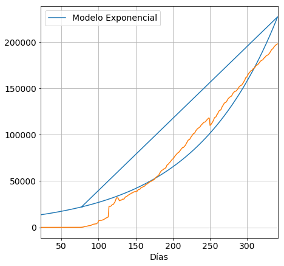

```python
# Implementar
# Función para añadir días a la predicción
def devolverDias(adicion):
    dias = x.copy()
    for dia in range(77,(77+adicion)):
        dias.append(dia)
    return dias

# Definición de función exponencial
def genExp(varIn, a, b):
    return a*np.exp(b*varIn)

exp_fit = curve_fit(genExp,x,y)
#print(exp_fit)

pred_x = list(range(0,max(x)+100))

# Creación de dataframes para el almacenamieto de los resultados
modeloExp = pd.DataFrame(columns=('Días', 'Modelo Exponencial'))
modeloPol = pd.DataFrame(columns=('Días', 'Modelo Polinomial'))
parametros, valoresCovarianza = curve_fit(genExp, x, y, p0=(0,0))

# Adicion de días para prediccion
dias = devolverDias(2)
puntos=[genExp(i,exp_fit[0][0],exp_fit[0][1]) for i in pred_x]
print ('Predicción a 7 días :', puntos[37], 'contagiados')
# Asignación de valores a la variable dependiente según la ecuación anterior
for pred in dias:
    modeloExp.loc[len(modeloExp)] = [pred,genExp(pred, parametros[0], parametros[1])]
# Gráfico del modelo exponencial
modeloExp.plot(x='Días', y='Modelo Exponencial')
plt.plot(df.loc[:,'date'],df.loc[:,'total_cases'])
plt.grid()
```

### Modelo polinomial

Predicción de una variable de respuesta cuantitativa a partir de una variable predictora cuantitativa, donde la relación se modela como una función polinomial de orden n (esto significa que pueden tener de diferentes exponenciales o grados y se debe ir probando)

Se puede tener una ecuacion con diferentes grados

y = a0 + a1x + a2x^2 + a3x^3 + … + anx^n + ε

Ejemplo de una regresion polinomica de grado 4.

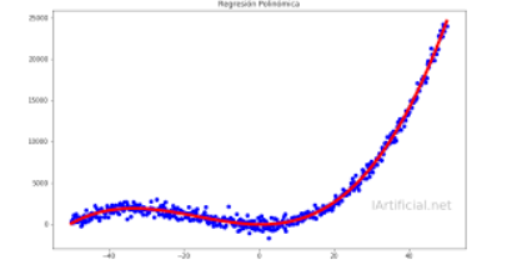

```python
df = pd.read_csv('owid-covid-data.csv')
df = df[df['location'].isin(['Ecuador'])&(df['total_cases']!=0)] #Filtro la Informacion solo para Ecuador
df
```

|  | iso_code | continent | location | date | total_cases | new_cases | new_cases_smoothed | total_deaths | new_deaths | new_deaths_smoothed | ... | gdp_per_capita | extreme_poverty | cardiovasc_death_rate | diabetes_prevalence | female_smokers | male_smokers | handwashing_facilities | hospital_beds_per_thousand | life_expectancy | human_development_index |
| --- | --- | --- | --- | --- | --- | --- | --- | --- | --- | --- | --- | --- | --- | --- | --- | --- | --- | --- | --- | --- | --- |
| 16001 | ECU | South America | Ecuador | 2020-01-23 | NaN | 0.0 | NaN | NaN | 0.0 | NaN | ... | 10581.936 | 3.6 | 140.448 | 5.55 | 2.0 | 12.3 | 80.635 | 1.5 | 77.01 | 0.752 |
| 16002 | ECU | South America | Ecuador | 2020-01-24 | NaN | 0.0 | NaN | NaN | 0.0 | NaN | ... | 10581.936 | 3.6 | 140.448 | 5.55 | 2.0 | 12.3 | 80.635 | 1.5 | 77.01 | 0.752 |
| 16003 | ECU | South America | Ecuador | 2020-01-25 | NaN | 0.0 | NaN | NaN | 0.0 | NaN | ... | 10581.936 | 3.6 | 140.448 | 5.55 | 2.0 | 12.3 | 80.635 | 1.5 | 77.01 | 0.752 |
| 16004 | ECU | South America | Ecuador | 2020-01-26 | NaN | 0.0 | NaN | NaN | 0.0 | NaN | ... | 10581.936 | 3.6 | 140.448 | 5.55 | 2.0 | 12.3 | 80.635 | 1.5 | 77.01 | 0.752 |
| 16005 | ECU | South America | Ecuador | 2020-01-27 | NaN | 0.0 | NaN | NaN | 0.0 | NaN | ... | 10581.936 | 3.6 | 140.448 | 5.55 | 2.0 | 12.3 | 80.635 | 1.5 | 77.01 | 0.752 |
| 16006 | ECU | South America | Ecuador | 2020-01-28 | NaN | 0.0 | 0.000 | NaN | 0.0 | 0.000 | ... | 10581.936 | 3.6 | 140.448 | 5.55 | 2.0 | 12.3 | 80.635 | 1.5 | 77.01 | 0.752 |
| 16007 | ECU | South America | Ecuador | 2020-01-29 | NaN | 0.0 | 0.000 | NaN | 0.0 | 0.000 | ... | 10581.936 | 3.6 | 140.448 | 5.55 | 2.0 | 12.3 | 80.635 | 1.5 | 77.01 | 0.752 |
| 16008 | ECU | South America | Ecuador | 2020-01-30 | NaN | 0.0 | 0.000 | NaN | 0.0 | 0.000 | ... | 10581.936 | 3.6 | 140.448 | 5.55 | 2.0 | 12.3 | 80.635 | 1.5 | 77.01 | 0.752 |
| 16009 | ECU | South America | Ecuador | 2020-01-31 | NaN | 0.0 | 0.000 | NaN | 0.0 | 0.000 | ... | 10581.936 | 3.6 | 140.448 | 5.55 | 2.0 | 12.3 | 80.635 | 1.5 | 77.01 | 0.752 |
| 16010 | ECU | South America | Ecuador | 2020-02-01 | NaN | 0.0 | 0.000 | NaN | 0.0 | 0.000 | ... | 10581.936 | 3.6 | 140.448 | 5.55 | 2.0 | 12.3 | 80.635 | 1.5 | 77.01 | 0.752 |
| 16011 | ECU | South America | Ecuador | 2020-02-02 | NaN | 0.0 | 0.000 | NaN | 0.0 | 0.000 | ... | 10581.936 | 3.6 | 140.448 | 5.55 | 2.0 | 12.3 | 80.635 | 1.5 | 77.01 | 0.752 |
| 16012 | ECU | South America | Ecuador | 2020-02-03 | NaN | 0.0 | 0.000 | NaN | 0.0 | 0.000 | ... | 10581.936 | 3.6 | 140.448 | 5.55 | 2.0 | 12.3 | 80.635 | 1.5 | 77.01 | 0.752 |
| 16013 | ECU | South America | Ecuador | 2020-02-04 | NaN | 0.0 | 0.000 | NaN | 0.0 | 0.000 | ... | 10581.936 | 3.6 | 140.448 | 5.55 | 2.0 | 12.3 | 80.635 | 1.5 | 77.01 | 0.752 |
| 16014 | ECU | South America | Ecuador | 2020-02-05 | NaN | 0.0 | 0.000 | NaN | 0.0 | 0.000 | ... | 10581.936 | 3.6 | 140.448 | 5.55 | 2.0 | 12.3 | 80.635 | 1.5 | 77.01 | 0.752 |
| 16015 | ECU | South America | Ecuador | 2020-02-06 | NaN | 0.0 | 0.000 | NaN | 0.0 | 0.000 | ... | 10581.936 | 3.6 | 140.448 | 5.55 | 2.0 | 12.3 | 80.635 | 1.5 | 77.01 | 0.752 |
| 16016 | ECU | South America | Ecuador | 2020-02-07 | NaN | 0.0 | 0.000 | NaN | 0.0 | 0.000 | ... | 10581.936 | 3.6 | 140.448 | 5.55 | 2.0 | 12.3 | 80.635 | 1.5 | 77.01 | 0.752 |
| 16017 | ECU | South America | Ecuador | 2020-02-08 | NaN | 0.0 | 0.000 | NaN | 0.0 | 0.000 | ... | 10581.936 | 3.6 | 140.448 | 5.55 | 2.0 | 12.3 | 80.635 | 1.5 | 77.01 | 0.752 |
| 16018 | ECU | South America | Ecuador | 2020-02-09 | NaN | 0.0 | 0.000 | NaN | 0.0 | 0.000 | ... | 10581.936 | 3.6 | 140.448 | 5.55 | 2.0 | 12.3 | 80.635 | 1.5 | 77.01 | 0.752 |
| 16019 | ECU | South America | Ecuador | 2020-02-10 | NaN | 0.0 | 0.000 | NaN | 0.0 | 0.000 | ... | 10581.936 | 3.6 | 140.448 | 5.55 | 2.0 | 12.3 | 80.635 | 1.5 | 77.01 | 0.752 |
| 16020 | ECU | South America | Ecuador | 2020-02-11 | NaN | 0.0 | 0.000 | NaN | 0.0 | 0.000 | ... | 10581.936 | 3.6 | 140.448 | 5.55 | 2.0 | 12.3 | 80.635 | 1.5 | 77.01 | 0.752 |
| 16021 | ECU | South America | Ecuador | 2020-02-12 | NaN | 0.0 | 0.000 | NaN | 0.0 | 0.000 | ... | 10581.936 | 3.6 | 140.448 | 5.55 | 2.0 | 12.3 | 80.635 | 1.5 | 77.01 | 0.752 |
| 16022 | ECU | South America | Ecuador | 2020-02-13 | NaN | 0.0 | 0.000 | NaN | 0.0 | 0.000 | ... | 10581.936 | 3.6 | 140.448 | 5.55 | 2.0 | 12.3 | 80.635 | 1.5 | 77.01 | 0.752 |
| 16023 | ECU | South America | Ecuador | 2020-02-14 | NaN | 0.0 | 0.000 | NaN | 0.0 | 0.000 | ... | 10581.936 | 3.6 | 140.448 | 5.55 | 2.0 | 12.3 | 80.635 | 1.5 | 77.01 | 0.752 |
| 16024 | ECU | South America | Ecuador | 2020-02-15 | NaN | 0.0 | 0.000 | NaN | 0.0 | 0.000 | ... | 10581.936 | 3.6 | 140.448 | 5.55 | 2.0 | 12.3 | 80.635 | 1.5 | 77.01 | 0.752 |
| 16025 | ECU | South America | Ecuador | 2020-02-16 | NaN | 0.0 | 0.000 | NaN | 0.0 | 0.000 | ... | 10581.936 | 3.6 | 140.448 | 5.55 | 2.0 | 12.3 | 80.635 | 1.5 | 77.01 | 0.752 |
| 16026 | ECU | South America | Ecuador | 2020-02-17 | NaN | 0.0 | 0.000 | NaN | 0.0 | 0.000 | ... | 10581.936 | 3.6 | 140.448 | 5.55 | 2.0 | 12.3 | 80.635 | 1.5 | 77.01 | 0.752 |
| 16027 | ECU | South America | Ecuador | 2020-02-18 | NaN | 0.0 | 0.000 | NaN | 0.0 | 0.000 | ... | 10581.936 | 3.6 | 140.448 | 5.55 | 2.0 | 12.3 | 80.635 | 1.5 | 77.01 | 0.752 |
| 16028 | ECU | South America | Ecuador | 2020-02-19 | NaN | 0.0 | 0.000 | NaN | 0.0 | 0.000 | ... | 10581.936 | 3.6 | 140.448 | 5.55 | 2.0 | 12.3 | 80.635 | 1.5 | 77.01 | 0.752 |
| 16029 | ECU | South America | Ecuador | 2020-02-20 | NaN | 0.0 | 0.000 | NaN | 0.0 | 0.000 | ... | 10581.936 | 3.6 | 140.448 | 5.55 | 2.0 | 12.3 | 80.635 | 1.5 | 77.01 | 0.752 |
| 16030 | ECU | South America | Ecuador | 2020-02-21 | NaN | 0.0 | 0.000 | NaN | 0.0 | 0.000 | ... | 10581.936 | 3.6 | 140.448 | 5.55 | 2.0 | 12.3 | 80.635 | 1.5 | 77.01 | 0.752 |
| ... | ... | ... | ... | ... | ... | ... | ... | ... | ... | ... | ... | ... | ... | ... | ... | ... | ... | ... | ... | ... | ... |
| 16291 | ECU | South America | Ecuador | 2020-11-08 | 174907.0 | 1421.0 | 816.143 | 12830.0 | 15.0 | 20.857 | ... | 10581.936 | 3.6 | 140.448 | 5.55 | 2.0 | 12.3 | 80.635 | 1.5 | 77.01 | 0.752 |
| 16292 | ECU | South America | Ecuador | 2020-11-09 | 175269.0 | 362.0 | 815.286 | 12839.0 | 9.0 | 21.000 | ... | 10581.936 | 3.6 | 140.448 | 5.55 | 2.0 | 12.3 | 80.635 | 1.5 | 77.01 | 0.752 |
| 16293 | ECU | South America | Ecuador | 2020-11-10 | 175711.0 | 442.0 | 800.143 | 12849.0 | 10.0 | 21.571 | ... | 10581.936 | 3.6 | 140.448 | 5.55 | 2.0 | 12.3 | 80.635 | 1.5 | 77.01 | 0.752 |
| 16294 | ECU | South America | Ecuador | 2020-11-11 | 176630.0 | 919.0 | 742.429 | 12920.0 | 71.0 | 30.857 | ... | 10581.936 | 3.6 | 140.448 | 5.55 | 2.0 | 12.3 | 80.635 | 1.5 | 77.01 | 0.752 |
| 16295 | ECU | South America | Ecuador | 2020-11-12 | 177513.0 | 883.0 | 818.571 | 12946.0 | 26.0 | 30.857 | ... | 10581.936 | 3.6 | 140.448 | 5.55 | 2.0 | 12.3 | 80.635 | 1.5 | 77.01 | 0.752 |
| 16296 | ECU | South America | Ecuador | 2020-11-13 | 178674.0 | 1161.0 | 880.857 | 12977.0 | 31.0 | 30.857 | ... | 10581.936 | 3.6 | 140.448 | 5.55 | 2.0 | 12.3 | 80.635 | 1.5 | 77.01 | 0.752 |
| 16297 | ECU | South America | Ecuador | 2020-11-14 | 179627.0 | 953.0 | 877.286 | 12997.0 | 20.0 | 26.000 | ... | 10581.936 | 3.6 | 140.448 | 5.55 | 2.0 | 12.3 | 80.635 | 1.5 | 77.01 | 0.752 |
| 16298 | ECU | South America | Ecuador | 2020-11-15 | 180295.0 | 668.0 | 769.714 | 13008.0 | 11.0 | 25.429 | ... | 10581.936 | 3.6 | 140.448 | 5.55 | 2.0 | 12.3 | 80.635 | 1.5 | 77.01 | 0.752 |
| 16299 | ECU | South America | Ecuador | 2020-11-16 | 180676.0 | 381.0 | 772.429 | 13016.0 | 8.0 | 25.286 | ... | 10581.936 | 3.6 | 140.448 | 5.55 | 2.0 | 12.3 | 80.635 | 1.5 | 77.01 | 0.752 |
| 16300 | ECU | South America | Ecuador | 2020-11-17 | 181104.0 | 428.0 | 770.429 | 13025.0 | 9.0 | 25.143 | ... | 10581.936 | 3.6 | 140.448 | 5.55 | 2.0 | 12.3 | 80.635 | 1.5 | 77.01 | 0.752 |
| 16301 | ECU | South America | Ecuador | 2020-11-18 | 182250.0 | 1146.0 | 802.857 | 13052.0 | 27.0 | 18.857 | ... | 10581.936 | 3.6 | 140.448 | 5.55 | 2.0 | 12.3 | 80.635 | 1.5 | 77.01 | 0.752 |
| 16302 | ECU | South America | Ecuador | 2020-11-19 | 183246.0 | 996.0 | 819.000 | 13073.0 | 21.0 | 18.143 | ... | 10581.936 | 3.6 | 140.448 | 5.55 | 2.0 | 12.3 | 80.635 | 1.5 | 77.01 | 0.752 |
| 16303 | ECU | South America | Ecuador | 2020-11-20 | 183840.0 | 594.0 | 738.000 | 13095.0 | 22.0 | 16.857 | ... | 10581.936 | 3.6 | 140.448 | 5.55 | 2.0 | 12.3 | 80.635 | 1.5 | 77.01 | 0.752 |
| 16304 | ECU | South America | Ecuador | 2020-11-21 | 184876.0 | 1036.0 | 749.857 | 13139.0 | 44.0 | 20.286 | ... | 10581.936 | 3.6 | 140.448 | 5.55 | 2.0 | 12.3 | 80.635 | 1.5 | 77.01 | 0.752 |
| 16305 | ECU | South America | Ecuador | 2020-11-22 | 185643.0 | 767.0 | 764.000 | 13201.0 | 62.0 | 27.571 | ... | 10581.936 | 3.6 | 140.448 | 5.55 | 2.0 | 12.3 | 80.635 | 1.5 | 77.01 | 0.752 |
| 16306 | ECU | South America | Ecuador | 2020-11-23 | 185944.0 | 301.0 | 752.571 | 13225.0 | 24.0 | 29.857 | ... | 10581.936 | 3.6 | 140.448 | 5.55 | 2.0 | 12.3 | 80.635 | 1.5 | 77.01 | 0.752 |
| 16307 | ECU | South America | Ecuador | 2020-11-24 | 186436.0 | 492.0 | 761.714 | 13264.0 | 39.0 | 34.143 | ... | 10581.936 | 3.6 | 140.448 | 5.55 | 2.0 | 12.3 | 80.635 | 1.5 | 77.01 | 0.752 |
| 16308 | ECU | South America | Ecuador | 2020-11-25 | 187230.0 | 794.0 | 711.429 | 13288.0 | 24.0 | 33.714 | ... | 10581.936 | 3.6 | 140.448 | 5.55 | 2.0 | 12.3 | 80.635 | 1.5 | 77.01 | 0.752 |
| 16309 | ECU | South America | Ecuador | 2020-11-26 | 188138.0 | 908.0 | 698.857 | 13316.0 | 28.0 | 34.714 | ... | 10581.936 | 3.6 | 140.448 | 5.55 | 2.0 | 12.3 | 80.635 | 1.5 | 77.01 | 0.752 |
| 16310 | ECU | South America | Ecuador | 2020-11-27 | 189534.0 | 1396.0 | 813.429 | 13358.0 | 42.0 | 37.571 | ... | 10581.936 | 3.6 | 140.448 | 5.55 | 2.0 | 12.3 | 80.635 | 1.5 | 77.01 | 0.752 |
| 16311 | ECU | South America | Ecuador | 2020-11-28 | 190909.0 | 1375.0 | 861.857 | 13371.0 | 13.0 | 33.143 | ... | 10581.936 | 3.6 | 140.448 | 5.55 | 2.0 | 12.3 | 80.635 | 1.5 | 77.01 | 0.752 |
| 16312 | ECU | South America | Ecuador | 2020-11-29 | 192117.0 | 1208.0 | 924.857 | 13423.0 | 52.0 | 31.714 | ... | 10581.936 | 3.6 | 140.448 | 5.55 | 2.0 | 12.3 | 80.635 | 1.5 | 77.01 | 0.752 |
| 16313 | ECU | South America | Ecuador | 2020-11-30 | 192685.0 | 568.0 | 963.000 | 13461.0 | 38.0 | 33.714 | ... | 10581.936 | 3.6 | 140.448 | 5.55 | 2.0 | 12.3 | 80.635 | 1.5 | 77.01 | 0.752 |
| 16314 | ECU | South America | Ecuador | 2020-12-01 | 193673.0 | 988.0 | 1033.857 | 13501.0 | 40.0 | 33.857 | ... | 10581.936 | 3.6 | 140.448 | 5.55 | 2.0 | 12.3 | 80.635 | 1.5 | 77.01 | 0.752 |
| 16315 | ECU | South America | Ecuador | 2020-12-02 | 194876.0 | 1203.0 | 1092.286 | 13562.0 | 61.0 | 39.143 | ... | 10581.936 | 3.6 | 140.448 | 5.55 | 2.0 | 12.3 | 80.635 | 1.5 | 77.01 | 0.752 |
| 16316 | ECU | South America | Ecuador | 2020-12-03 | 195884.0 | 1008.0 | 1106.571 | 13612.0 | 50.0 | 42.286 | ... | 10581.936 | 3.6 | 140.448 | 5.55 | 2.0 | 12.3 | 80.635 | 1.5 | 77.01 | 0.752 |
| 16317 | ECU | South America | Ecuador | 2020-12-04 | 196482.0 | 598.0 | 992.571 | 13696.0 | 84.0 | 48.286 | ... | 10581.936 | 3.6 | 140.448 | 5.55 | 2.0 | 12.3 | 80.635 | 1.5 | 77.01 | 0.752 |
| 16318 | ECU | South America | Ecuador | 2020-12-05 | 197391.0 | 909.0 | 926.000 | 13756.0 | 60.0 | 55.000 | ... | 10581.936 | 3.6 | 140.448 | 5.55 | 2.0 | 12.3 | 80.635 | 1.5 | 77.01 | 0.752 |
| 16319 | ECU | South America | Ecuador | 2020-12-06 | 197998.0 | 607.0 | 840.143 | 13778.0 | 22.0 | 50.714 | ... | 10581.936 | 3.6 | 140.448 | 5.55 | 2.0 | 12.3 | 80.635 | 1.5 | 77.01 | 0.752 |
| 16320 | ECU | South America | Ecuador | 2020-12-07 | 198244.0 | 246.0 | 794.143 | 13780.0 | 2.0 | 45.571 | ... | 10581.936 | 3.6 | 140.448 | 5.55 | 2.0 | 12.3 | 80.635 | 1.5 | 77.01 | 0.752 |

320 rows × 50 columns

```python
df = pd.read_csv('owid-covid-data.csv').fillna(0) # poniendo datos nan a cero
ndf= df.loc[(df['location'] == 'Ecuador') & (df['total_cases'] != 0)] # filtrando por pais y no ceros
ndf1=ndf[['date','total_cases','total_deaths']]
x=np.arange(1,len(ndf1)+1,1, dtype='float') # arreglo de x lo creo para simular el numero del dia y el numero de casos
y=np.array(ndf1.values[:,1], dtype='float')
y1=np.array(ndf1.values[:,2],dtype='float')
```

### N° Casos

```
           4           3        2
1.477e-05 x - 0.01094 x + 3.75 x + 228.4 x - 3699
```

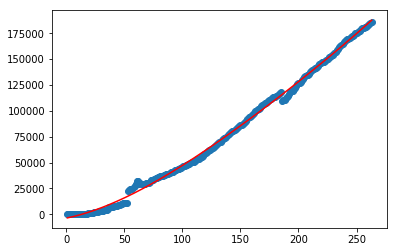

```python
fun1 = np.poly1d(np.polyfit(x, y, 4))
print(fun1)
plt.scatter(x, y)
plt.plot(x, fun1(x), c='r')
plt.show()
```

### N° Fallecidos

```
            4            3         2
-1.121e-05 x + 0.005449 x - 0.718 x + 70.69 x - 1003
```

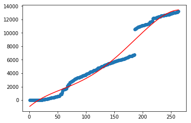

```python
fun1 = np.poly1d(np.polyfit(x, y1, 4))
print(fun1)
plt.scatter(x, y1)
plt.plot(x, fun1(x), c='r')
plt.show()
```

[figure not shown]

```python
# Obtención de la ecuación polinomial de grado 'n'
y_polinomial = np.poly1d(np.polyfit(x,y,6))
# Asignación de valores a la variable dependiente según la ecuación anterior
for pred in dias:
    modeloPol.loc[len(modeloPol)] = [pred, y_polinomial(pred)]
# Gráfico del modelo polinomial de grado 9
modeloPol.plot(x='Días',y='Modelo Polinomial')
plt.plot(df['date'], df['total_cases'])
plt.grid()
```

# Referencias

- https://www.researchgate.net/publication/340092755_Infeccion_del_Covid-19_en_Colombia_Una_comparacion_de_modelos_logisticos_y_exponenciales_aplicados_a_la_infeccion_por_el_virus_en_Colombia
- https://www.aprendemachinelearning.com/regresion-lineal-en-espanol-con-python/